# Prediction of beer consumption in Sao Paulo Brazil

The data (sample) was collected in São Paulo-Brazil The dataset used for this activity has 7 attributes/features. The data is recorded for a period of one year.

The goal is to determine what factors contribute to beer consumption and use an appropriate Machine learning model to predict the consumption of beer(litres per 1000 people).

##### **Loading required libraries:**

```r
library(dplyr)
library(ggplot2)
library(readr)
library(caret)
library(stringr)
library(purrr)
library(lubridate)
library(corrplot)
library(caretEnsemble)
library(shiny)
library(knitr)
library(e1071)
library(randomForest)
library(elasticnet)
library(boot)
library(forcats)
library(shinythemes)
library(kableExtra)
```

#### **Importing the data using the readr library.**

In the raw data commas are used as decimal points. readr reads the temperature data as integers and ignores the commas(23,2 degrees becomes 232 degrees) so we import the numeric values as characters and will convert them later on , replacing the commas with a decimal point

```r
beerdata<-read_csv('Consumo_cerveja.csv',col_types = cols(

  `Temperatura Media (C)` = col_character(),
  `Temperatura Minima (C)` = col_character(),
  `Temperatura Maxima (C)` = col_character(),
  `Precipitacao (mm)` = col_character(),
  `Final de Semana` = col_character()
))
```

```r
str(beerdata)
```

```
## Classes 'spec_tbl_df', 'tbl_df', 'tbl' and 'data.frame': 941 obs. of  7 variables:
##  $ Data                       : Date, format: "2015-01-01" "2015-01-02" ...
##  $ Temperatura Media (C)      : chr  "27,3" "27,02" "24,82" "23,98" ...
##  $ Temperatura Minima (C)     : chr  "23,9" "24,5" "22,4" "21,5" ...
##  $ Temperatura Maxima (C)     : chr  "32,5" "33,5" "29,9" "28,6" ...
##  $ Precipitacao (mm)          : chr  "0" "0" "0" "1,2" ...
##  $ Final de Semana            : chr  "0" "0" "1" "1" ...
##  $ Consumo de cerveja (litros): num  25.5 29 30.8 29.8 28.9 ...
##  - attr(*, "spec")=
##   .. cols(
##   ..   Data = col_date(format = ""),
##   ..   `Temperatura Media (C)` = col_character(),
##   ..   `Temperatura Minima (C)` = col_character(),
##   ..   `Temperatura Maxima (C)` = col_character(),
##   ..   `Precipitacao (mm)` = col_character(),
##   ..   `Final de Semana` = col_character(),
##   ..   `Consumo de cerveja (litros)` = col_double()
##   .. )
```

##### **Converting the column names from Portuguese to English**

```r
colnames(beerdata)<- c('date','mean_temp','min_temp','max_temp','rainfall','endofweek','beerconsumption')
```

```r
head(beerdata)
```

```
## # A tibble: 6 x 7
##   date       mean_temp min_temp max_temp rainfall endofweek beerconsumption
##   <date>     <chr>     <chr>    <chr>    <chr>    <chr>               <dbl>
## 1 2015-01-01 27,3      23,9     32,5     0        0                    25.5
## 2 2015-01-02 27,02     24,5     33,5     0        0                    29.0
## 3 2015-01-03 24,82     22,4     29,9     0        1                    30.8
## 4 2015-01-04 23,98     21,5     28,6     1,2      1                    29.8
## 5 2015-01-05 23,82     21       28,3     0        0                    28.9
## 6 2015-01-06 23,78     20,1     30,5     12,2     0                    28.2
```

##### **Trimming the dataset to include only the first 365 rows as the data only pertains to one year and the remainig values are NULL.**

```r
beerdata<-beerdata[ 1:365,]
tail(beerdata)
```

```
## # A tibble: 6 x 7
##   date       mean_temp min_temp max_temp rainfall endofweek beerconsumption
##   <date>     <chr>     <chr>    <chr>    <chr>    <chr>               <dbl>
## 1 2015-12-26 23,34     17,8     29,8     94,8     1                    22.0
## 2 2015-12-27 24        21,1     28,2     13,6     1                    32.3
## 3 2015-12-28 22,64     21,1     26,7     0        0                    26.1
## 4 2015-12-29 21,68     20,3     24,1     10,3     0                    22.3
## 5 2015-12-30 21,38     19,3     22,4     6,3      0                    20.5
## 6 2015-12-31 24,76     20,2     29       0        0                    22.4
```

##### **Replacing commas with decimal points**

```r
removecomma <- function(x){
x<-str_replace(x,',','.')
return(x)
}
```

```r
beerdata$min_temp<-beerdata$min_temp%>%map_chr(removecomma)
beerdata$max_temp<-beerdata$max_temp%>%map_chr(removecomma)
beerdata$mean_temp<-beerdata$mean_temp%>%map_chr(removecomma)
beerdata$rainfall<-beerdata$rainfall%>%map_chr(removecomma)
```

```r
for(i in 2:5){
  beerdata[[i]]<-as.double(beerdata[[i]])
}
```

##### **Checking for NULL values**

```r
sum(is.na(beerdata))
```

```
## [1] 0
```

##### **FINAL DATA:**

```r
head(beerdata)%>%kbl()%>%kable_material_dark(c('striped','hover'))
```

| date | mean_temp | min_temp | max_temp | rainfall | endofweek | beerconsumption |
| --- | --- | --- | --- | --- | --- | --- |
| 2015-01-01 | 27.30 | 23.9 | 32.5 | 0.0 | 0 | 25.461 |
| 2015-01-02 | 27.02 | 24.5 | 33.5 | 0.0 | 0 | 28.972 |
| 2015-01-03 | 24.82 | 22.4 | 29.9 | 0.0 | 1 | 30.814 |
| 2015-01-04 | 23.98 | 21.5 | 28.6 | 1.2 | 1 | 29.799 |
| 2015-01-05 | 23.82 | 21.0 | 28.3 | 0.0 | 0 | 28.900 |
| 2015-01-06 | 23.78 | 20.1 | 30.5 | 12.2 | 0 | 28.218 |

```r
beerdata[[6]]<-as.double(beerdata[[6]])
```

##### **Adding day of week as a new column**

```r
beerdata<-beerdata%>%mutate(dayofweek=wday(beerdata$date,label = TRUE))
```

##### **There is a marked increase in beer consumtion on SATUDRAY and SUNDAY**

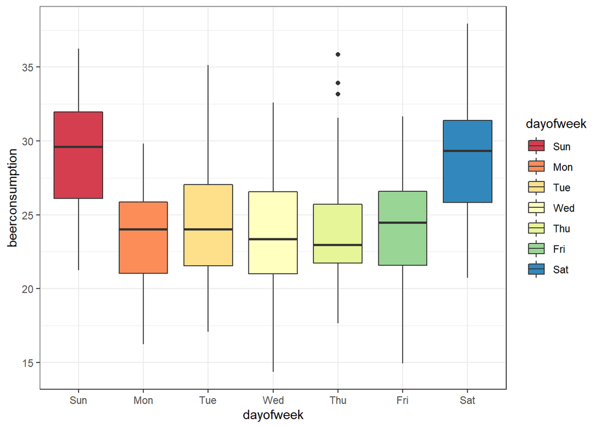

```r
ggplot(data=beerdata,aes(x=dayofweek,y=beerconsumption))+geom_boxplot(aes(fill=dayofweek))+

scale_fill_brewer(palette = 'Spectral')+theme_bw()
```

##### **There seems to be a positive relationship between temperature and beer consumption fo evey day of the week. A linear model is likely to perform well if temperature is indeed an important feature.**

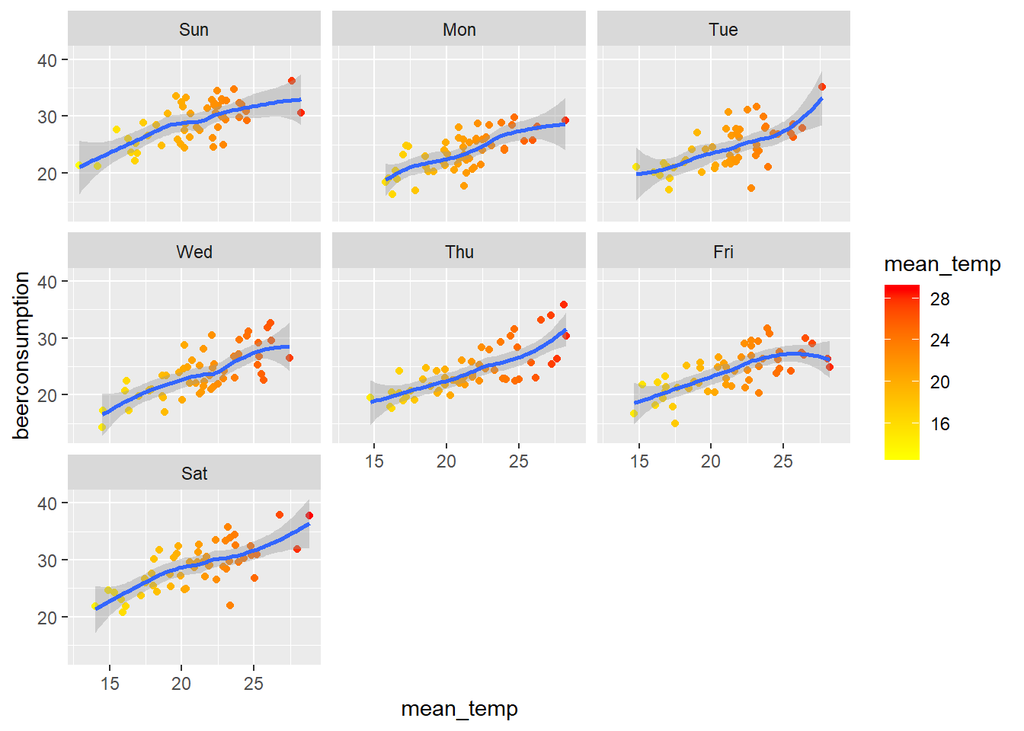

```r
ggplot(data=beerdata,aes(x=mean_temp,y=beerconsumption))+geom_point(aes(color=mean_temp))+
  geom_smooth()+facet_wrap(~dayofweek)+scale_color_gradient(low="yellow", high="red")
```

##### **Adding the month to the data we notice that the consumption of beer dips towards the middle of the year but not by much**

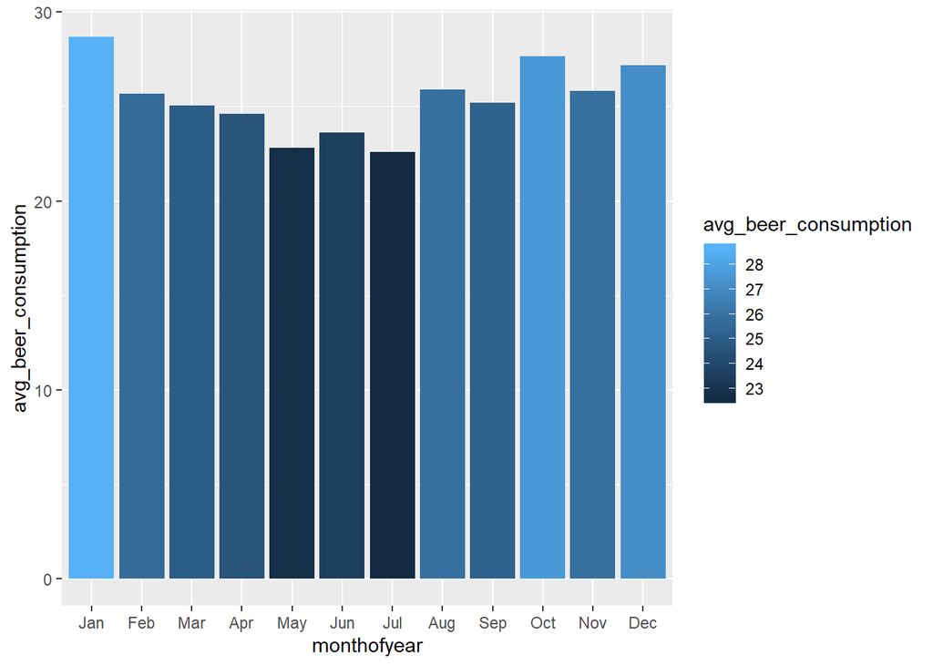

```r
beerdata%>%mutate(monthofyear=month(date,label = TRUE))%>%group_by(monthofyear)%>%summarise(avg_beer_consumption=mean(beerconsumption))%>%ggplot(aes(x=monthofyear,y=avg_beer_consumption,fill=avg_beer_consumption))+geom_bar(stat = 'identity')
```

##### **None of the features are too correlated with beer consumtion.**

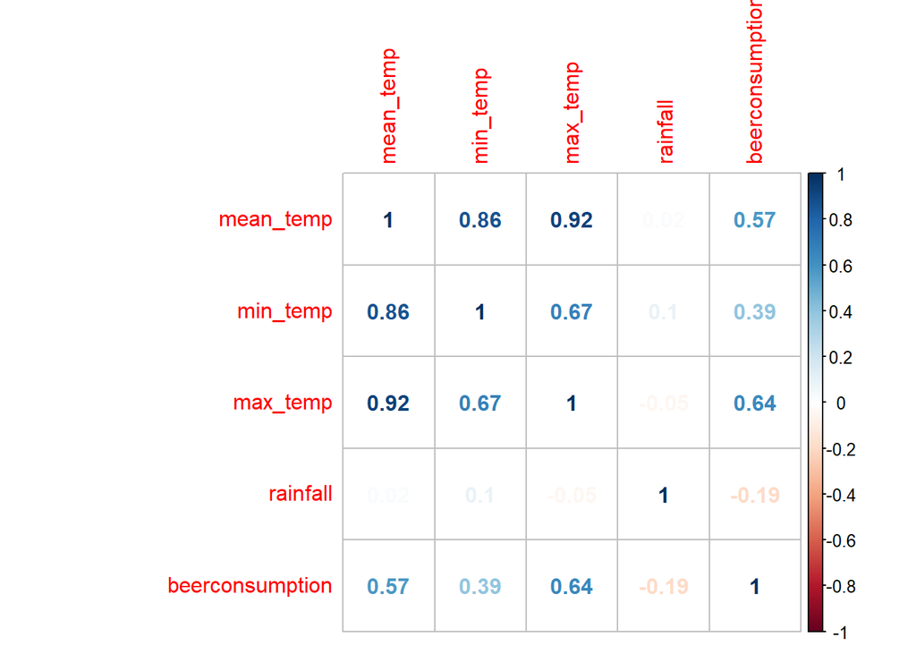

```r
correlation<-cor(beerdata%>%select(-c(date,endofweek,dayofweek)))
corrplot(correlation, method="number")
```

#### **Finding important features using a random forest model**

```r
control <- trainControl(method="repeatedcv", number=5, repeats=3)

model <- train(beerconsumption~., data=beerdata%>%select(-c(date,dayofweek)), method="rf", preProcess="scale", trControl=control)
importance <- varImp(model, scale=FALSE)

print(importance)
```

```
## rf variable importance
##
##           Overall
## max_temp   2424.9
## endofweek  1579.1
## mean_temp  1426.6
## min_temp    763.9
## rainfall    464.7
```

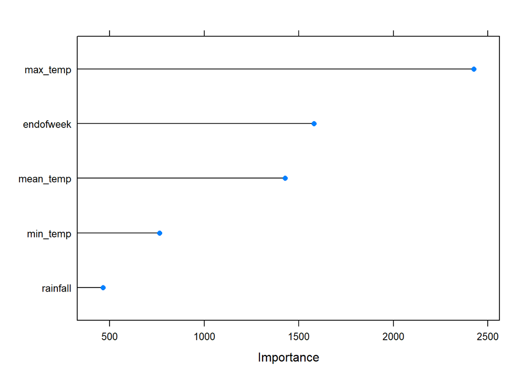

```r
plot(importance)
```

##### **Since the goal is prediction and not inference we include more than one temperature feature even though they are correlated. Choosing the temperature variables and end-of-week as the final features and split the data into test and train datasets**

```r
beerdata<-beerdata%>%select(max_temp,endofweek,min_temp,mean_temp,beerconsumption)

trainIndex <- createDataPartition(beerdata$beerconsumption, p = .8,
                                  list = FALSE,
                                  times = 1)

Train <- beerdata[ trainIndex,]
Test  <- beerdata[-trainIndex,]

head(Test)
```

```
## # A tibble: 6 x 5
##   max_temp endofweek min_temp mean_temp beerconsumption
##      <dbl>     <dbl>    <dbl>     <dbl>           <dbl>
## 1     29.9         1     22.4      24.8            30.8
## 2     30.5         0     20.1      23.8            28.2
## 3     35.4         0     21.4      26.0            25.7
## 4     35.6         0     23.3      27.7            35.1
## 5     30.9         0     22.7      25.3            29.1
## 6     26.1         0     19.2      21.7            25.8
```

##### **Running 5 fold cross validation on five different models**

- linear regression
- LASSO
- RIDGE
- Random Forest
- K neares neighbours

```r
fitControl <- trainControl(method = "cv",   number = 5,
                           savePredictions = 'final',allowParallel = TRUE)

models<-caretList(beerconsumption ~., data = Train,methodList =  c("lm","rf","lasso","ridge","knn"),
             preProcess=c('center','scale'),
             trControl = fitControl)
```

##### **Linear regression and Ridge models provided the lowest root mean squared error overall**

```r
model_results <- data.frame(
 LM = mean(models$lm$results$RMSE),
 KNN = mean(models$knn$results$RMSE),
 RF = mean(models$rf$results$RMSE),
 LASSO = mean(models$lasso$results$RMSE),
 RIDGE = mean(models$ridge$results$RMSE)
 )
print(model_results)
```

```
##         LM      KNN       RF    LASSO    RIDGE
## 1 2.404915 2.632889 2.721741 3.111862 2.407529
```

[output not shown]

Shiny applications not supported in static R Markdown documents